# Missing values impact

# Simulated data (variable n)

```r
S = 5
grid = seq(0,0.8,0.2)

argsL = list(n=c(100, 200, 500, 1000),
            rho= 0.7,
            sigma_reg = 0.3,
            train_prop=0.7,
            miss_prop.train=grid,
            miss_prop.test=grid,
            p=5
)

res = evaluate.S.run.multiArg(S,argsL, oneRun, do.parallel = T)
```

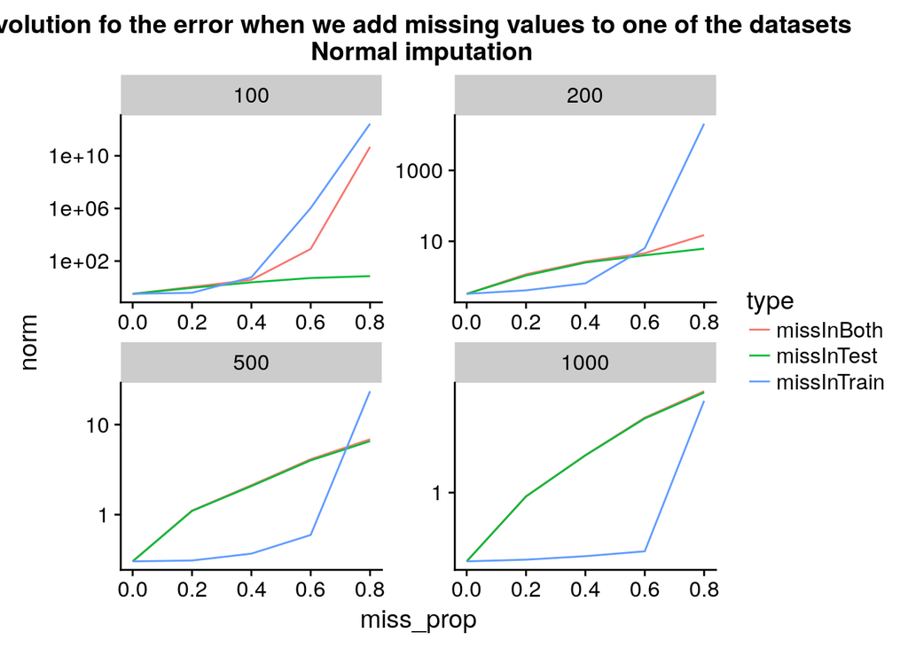

```r
res.fullTrain = res %>% filter(miss_prop.train ==0) %>% mutate(type='missInTest', miss_prop=miss_prop.test)
res.fullTest = res %>% filter(miss_prop.test == 0) %>% mutate(type='missInTrain', miss_prop=miss_prop.train)
res.both = res %>% filter(miss_prop.test == miss_prop.train) %>% mutate(type='missInBoth', miss_prop=miss_prop.train)
res.stack = rbind(res.fullTest, res.fullTrain,res.both)
ggplot(res.stack) + aes(x=miss_prop, y=norm, color=type) + geom_line() + facet_wrap(~n, scale='free') + scale_y_log10() +
  ggtitle('Evolution fo the error when we add missing values to one of the datasets \n Normal imputation')
```

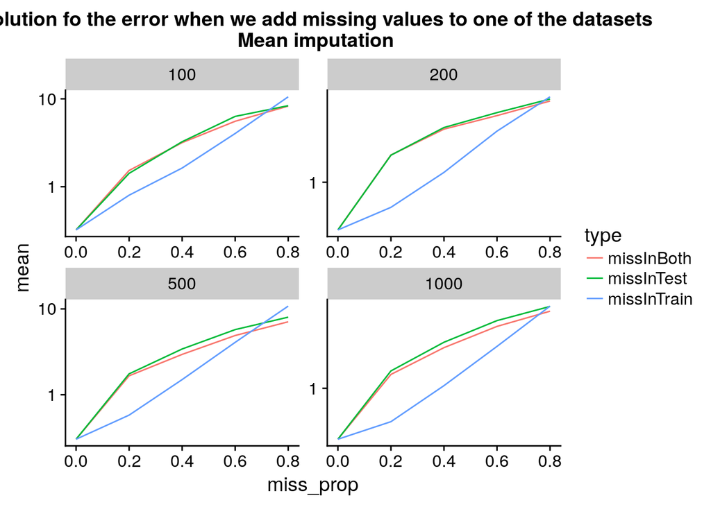

```r
res.fullTrain = res %>% filter(miss_prop.train ==0) %>% mutate(type='missInTest', miss_prop=miss_prop.test)
res.fullTest = res   %>% filter(miss_prop.test == 0) %>% mutate(type='missInTrain', miss_prop=miss_prop.train)
res.both = res %>% filter(miss_prop.test == miss_prop.train) %>% mutate(type='missInBoth', miss_prop=miss_prop.train)
res.stack = rbind(res.fullTest, res.fullTrain,res.both)
ggplot(res.stack) + aes(x=miss_prop, y=mean, color=type) + geom_line() + facet_wrap(~n, scale='free') + scale_y_log10() +
  ggtitle('Evolution fo the error when we add missing values to one of the datasets \n Mean imputation')
```

## Abalone data

Here we do the same with the real-world Abalone data, where the goal is to determine the age of a shell based on physical measurements. The data has n=4000 observations with p=7 variables, and the columns are very correlated with one another.

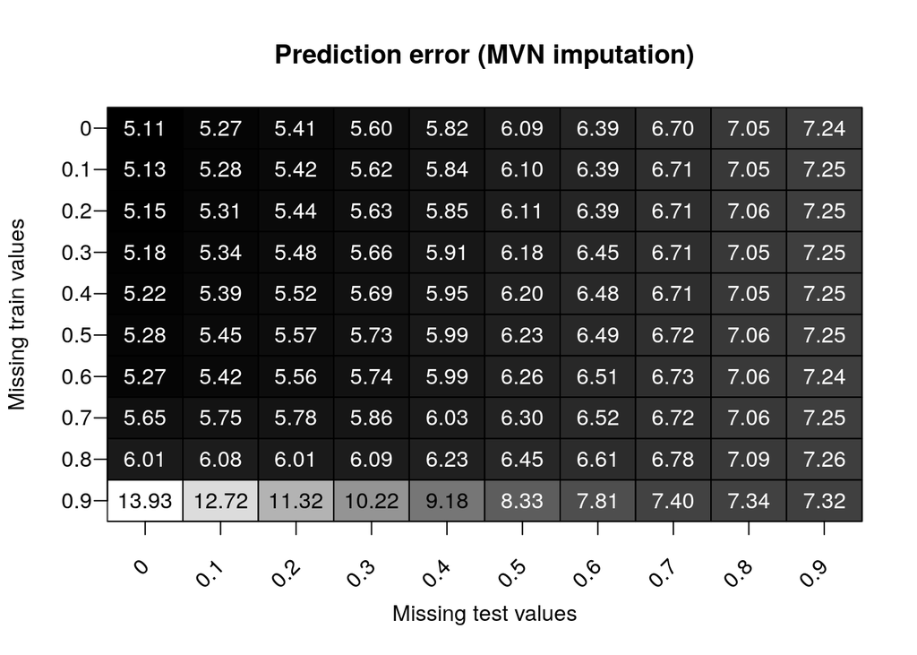

```r
grid = seq(0,0.9,0.1)
predictor = reg.lin
errFun = function(y.pred,y.test){mean((y.pred-y.test)^2)}
X.gen = X.abalone
y.gen = y.abalone
argsL = list(n=2000,
          #  rho=0.5,
            sigma_reg = 0.3,
            train_prop=0.7,
            miss_prop.train=grid,
            miss_prop.test=grid
)

S = 10
res = evaluate.S.run.multiArg(S,argsL, oneRun, do.parallel = T)

res.grid = matrix(NA, nrow=length(grid), ncol=length(grid))
for(i in 1:nrow(res)){
  missTr = res$miss_prop.train[i]
  missTe = res$miss_prop.test[i]
  iTr = which(grid==missTr)
  iTe = which(grid==missTe)
  res.grid[iTr,iTe] = res$norm[i]
}

tlab = 0.5:(length(grid)-0.5)
lab = grid
res.grid %>% as.data.frame() %>%color2D.matplot(show.values=2, axes=F, xlab='Missing test values', ylab='Missing train values')
axis(1, at=tlab, labels=F)
text(x=tlab, y=par()$usr[3]-0.1*(par()$usr[4]-par()$usr[3]),
     labels=lab, srt=45, adj=1, xpd=T)
axis(2, at=tlab, labels=F)
text(y=tlab, x=par()$usr[1] -0.02*(par()$usr[2]-par()$usr[1]),
     labels=rev(lab), srt=0, adj=1, xpd=T)
title('Prediction error (MVN imputation)')
```

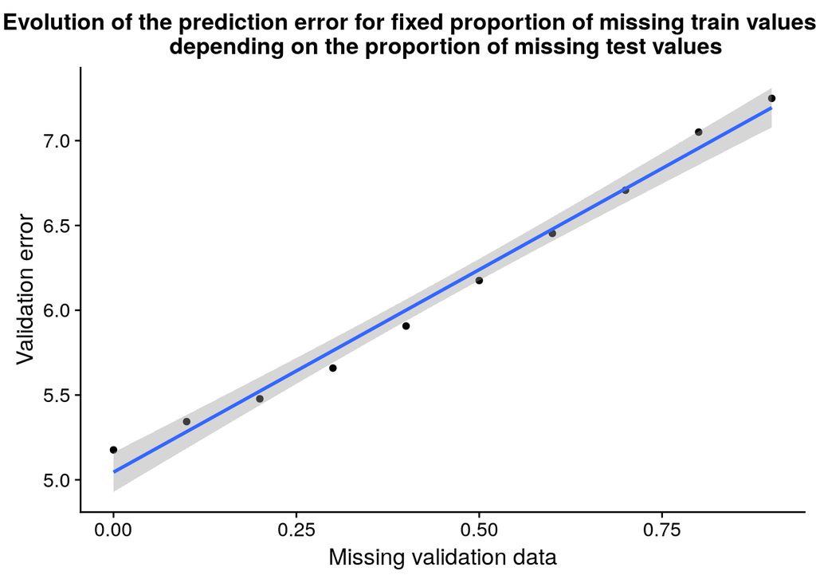

```r
ggplot() + aes(x=grid, y=res.grid[4,]) + geom_point() + ggtitle('Evolution of the prediction error for fixed proportion of missing train values(30%) \n depending on the proportion of missing test values') + xlab('Missing validation data') + ylab('Validation error') +
  geom_smooth(method='lm')
```

We notice the same dynamics as before, although they are less marked in real-world data. A striking difference if that in this case the mean imputation breaks down when a lot of training data is missing, while the normal imputation does not. This might be related to the very high correlation between the variables which makes it particularly relevant to perform an imputation which does not ignore those correlations.

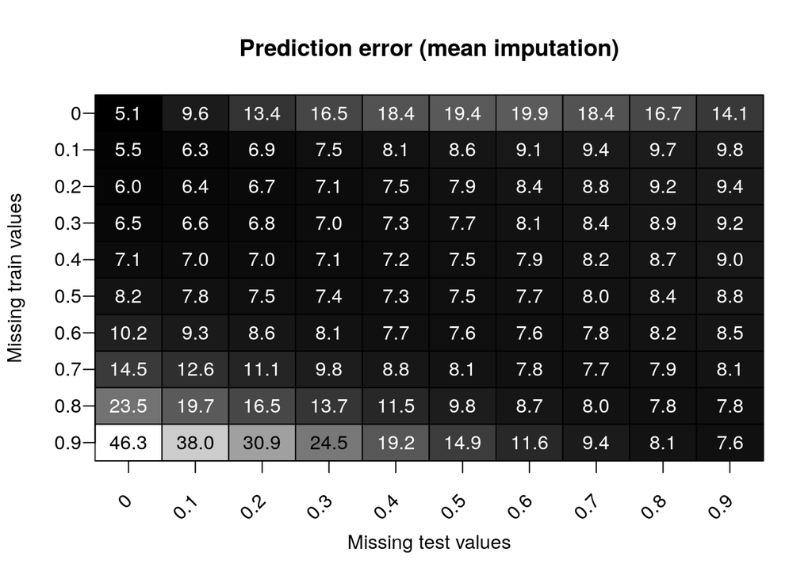

```r
res.grid = matrix(NA, nrow=length(grid), ncol=length(grid))
for(i in 1:nrow(res)){
  missTr = res$miss_prop.train[i]
  missTe = res$miss_prop.test[i]
  iTr = which(grid==missTr)
  iTe = which(grid==missTe)
  res.grid[iTr,iTe] = res$mean[i]
}

tlab = 0.5:(length(grid)-0.5)
lab = grid
res.grid %>% as.data.frame() %>%color2D.matplot(show.values=1, axes=F, xlab='Missing test values', ylab='Missing train values')
axis(1, at=tlab, labels=F)
text(x=tlab, y=par()$usr[3]-0.1*(par()$usr[4]-par()$usr[3]),
     labels=lab, srt=45, adj=1, xpd=T)
axis(2, at=tlab, labels=F)
text(y=tlab, x=par()$usr[1] -0.02*(par()$usr[2]-par()$usr[1]),
     labels=rev(lab), srt=0, adj=1, xpd=T)
title('Prediction error (mean imputation)')
```

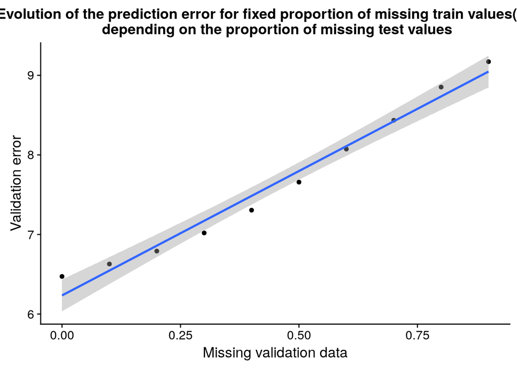

```r
ggplot() + aes(x=grid, y=res.grid[4,]) + geom_point() + ggtitle('Evolution of the prediction error for fixed proportion of missing train values(30%) \n depending on the proportion of missing test values') + xlab('Missing validation data') + ylab('Validation error') +
  geom_smooth(method='lm')
```

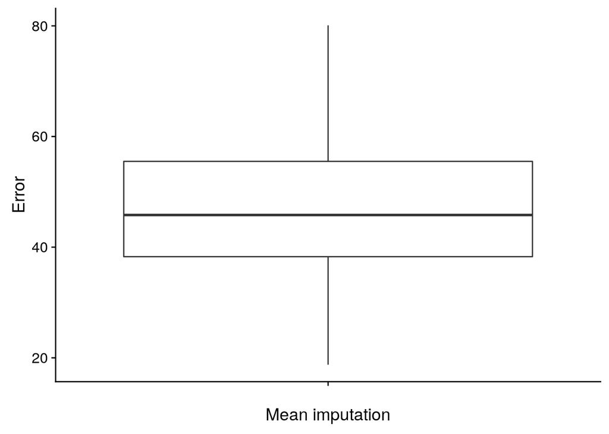

```r
S = 100
args = list(n=800, rho=0.5, train_prop=0.7, miss_prop.train=0.9, miss_prop.test=0,p=5, sigma_reg=0.3)
res = evaluate.S.run.general(S,args,oneRun)
ggplot() + aes(y=res$mean, x='') + geom_boxplot() + ylab('Error') + xlab('Mean imputation')
```

## Abalone data (variable n)

To investigate the impact of sample size on the difference between traning and validation data, we experiment with multiple values for n.

```r
S = 5
grid = seq(0,0.8,0.2)
predictor = reg.lin
errFun = function(y.pred,y.test){mean((y.pred-y.test)^2)}
X.gen = X.abalone
y.gen = y.abalone
argsL = list(n=c(200,500, 1000, 4000),
          #  rho=0.5,
            sigma_reg = 0.3,
            train_prop=0.7,
            miss_prop.train=grid,
            miss_prop.test=grid
)

res = evaluate.S.run.multiArg(S,argsL, oneRun, do.parallel = T)
```

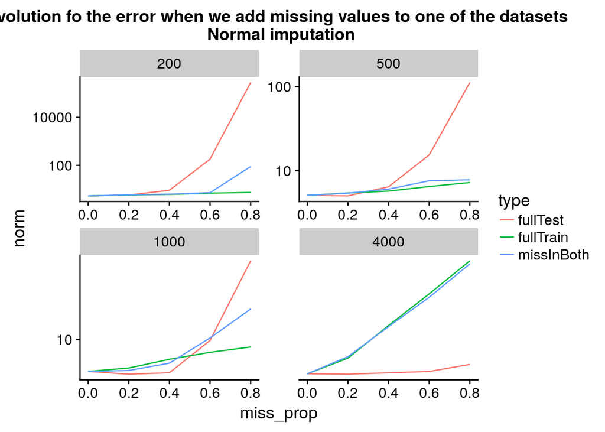

```r
res.fullTrain = res %>% filter(miss_prop.train ==0) %>% mutate(type='fullTrain', miss_prop=miss_prop.test)
res.fullTest = res %>% filter(miss_prop.test == 0) %>% mutate(type='fullTest', miss_prop=miss_prop.train)
res.both = res %>% filter(miss_prop.test == miss_prop.train) %>% mutate(type='missInBoth', miss_prop=miss_prop.train)
res.stack = rbind(res.fullTest, res.fullTrain,res.both)
ggplot(res.stack) + aes(x=miss_prop, y=norm, color=type) + geom_line() + facet_wrap(~n, scale='free') + scale_y_log10() +
  ggtitle('Evolution fo the error when we add missing values to one of the datasets \n Normal imputation')
```

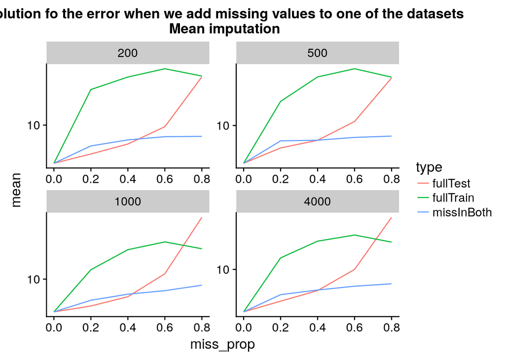

```r
res.fullTrain = res %>% filter(miss_prop.train ==0) %>% mutate(type='fullTrain', miss_prop=miss_prop.test)
res.fullTest = res %>% filter(miss_prop.test == 0) %>% mutate(type='fullTest', miss_prop=miss_prop.train)
res.both = res %>% filter(miss_prop.test == miss_prop.train) %>% mutate(type='missInBoth', miss_prop=miss_prop.train)
res.stack = rbind(res.fullTest, res.fullTrain,res.both)
ggplot(res.stack) + aes(x=miss_prop, y=mean, color=type) + geom_line() + facet_wrap(~n, scale='free') + scale_y_log10() +
  ggtitle('Evolution fo the error when we add missing values to one of the datasets \n Mean imputation')
```